# General least squares for linear equations

## General least squares for linear equations

Consider again the parent and child height data from Galton

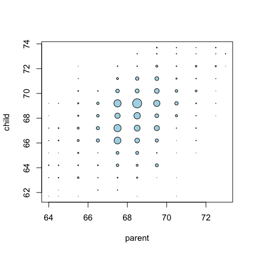

## Fitting the best line

- In the previous figure, the size of the dots represents the number of observations with that same data point.
- Let \( Y_i \) be the \( i^{th} \) child's height and \( X_i \) be the \( i^{th} \) (average over the pair of) parents' heights.
- Consider finding the best line
  - Child's Height = \( \beta_0 \) + Parent's Height \( \beta_1 \)
- Use least squares \[ \sum_{i=1}^n \{Y_i - (\beta_0 + \beta_1 X_i)\}^2 \]
- Notice that \( (\beta_0 + \beta_1 X_i) \) is the predicted height of the child (and it's also the regression line),
- while \( Y_i \) is the observed height of the child.
- Thus we are summing the (squares of the) differences between observed and predicted values.
- How do we do it?

## Let's solve this problem generally

- Let \( \mu_i = \beta_0 + \beta_1 X_i \) and our estimates be \( \hat \mu_i = \hat \beta_0 + \hat \beta_1 X_i \).
  - \( \mu_i \) and \( \hat{\mu}_i \) simply exist to reduce notation.
  - So \( \hat{\mu}_i \) is our fitted line.
- We want to minimize \[ \dagger \sum_{i=1}^n (Y_i - \mu_i)^2 = \sum_{i=1}^n (Y_i - \hat \mu_i) ^ 2 + 2 \sum_{i=1}^n (Y_i - \hat \mu_i) (\hat \mu_i - \mu_i) + \sum_{i=1}^n (\hat \mu_i - \mu_i)^2 \]
- Suppose that the middle term above is zero: \[ \sum_{i=1}^n (Y_i - \hat \mu_i) (\hat \mu_i - \mu_i) = 0 \] then \[ \dagger =\sum_{i=1}^n (Y_i - \hat \mu_i) ^ 2 + \sum_{i=1}^n (\hat \mu_i - \mu_i)^2\geq \sum_{i=1}^n (Y_i - \hat \mu_i) ^ 2 \]
- and we'll have the best \( \hat{\mu}_i \).

## Mean only regression

- So we know that if: \[ \sum_{i=1}^n (Y_i - \hat \mu_i) (\hat \mu_i - \mu_i) = 0 \] where \( \mu_i = \beta_0 + \beta_1 X_i \) and \( \hat \mu_i = \hat \beta_0 + \hat \beta_1 X_i \) then the line \[ Y = \hat \beta_0 + \hat \beta_1 X \] is the least squares line.
- Consider forcing \( \beta_1 = 0 \) and thus \( \hat \beta_1=0 \); that is, only considering horizontal lines
- The solution works out to be \[ \hat \beta_0 = \bar Y. \]

## Let's show it

\[ \begin{align} \ \sum_{i=1}^n (Y_i - \hat \mu_i) (\hat \mu_i - \mu_i) = & \sum_{i=1}^n (Y_i - \hat \beta_0) (\hat \beta_0 - \beta_0) \\ = & (\hat \beta_0 - \beta_0) \sum_{i=1}^n (Y_i - \hat \beta_0) \ \end{align} \]

Thus, this will equal 0 if \( \sum_{i=1}^n (Y_i - \hat \beta_0) = n\bar Y - n \hat \beta_0=0 \)

Thus \( \hat \beta_0 = \bar Y. \)

## Regression through the origin

- Recall that if: \[ \sum_{i=1}^n (Y_i - \hat \mu_i) (\hat \mu_i - \mu_i) = 0 \] where \( \mu_i = \beta_0 + \beta_1 X_i \) and \( \hat \mu_i = \hat \beta_0 + \hat \beta_1 X_i \) then the line \[ Y = \hat \beta_0 + \hat \beta_1 X \] is the least squares line.
- Consider forcing \( \beta_0 = 0 \) and thus \( \hat \beta_0=0 \); that is, only considering lines through the origin
- The solution works out to be \[ \hat \beta_1 = \frac{\sum_{i=1}^n Y_i X_i}{\sum_{i=1}^n X_i^2}. \]
- which is also described as being the inner product of \( Y \) and \( X \) divided by the inner product of \( X \) by itself, \[ \frac{\langle Y,X \rangle}{\langle X,X \rangle} \]

## Let's show it

\[ \begin{align} \ \sum_{i=1}^n (Y_i - \hat \mu_i) (\hat \mu_i - \mu_i) = & \sum_{i=1}^n (Y_i - \hat \beta_1 X_i) (\hat \beta_1 X_i - \beta_1 X_i) \\ = & (\hat \beta_1 - \beta_1) \sum_{i=1}^n (Y_i X_i - \hat \beta_1 X_i ^2) \ \end{align} \]

Thus, this will equal 0 if \( \sum_{i=1}^n (Y_i X_i - \hat \beta_1 X_i ^2) = \sum_{i=1}^n Y_i X_i - \hat \beta_1 \sum_{i=1}^n X_i^2 =0 \)

Thus \[ \hat \beta_1 = \frac{\sum_{i=1^n} Y_i X_i}{\sum_{i=1}^n X_i^2}. \]

## Recapping what we know

- If we define \( \mu_i = \beta_0 \) then \( \hat \beta_0 = \bar Y \).
  - If we only look at horizontal lines, the least squares estimate of the intercept of that line is the average of the outcomes.
- If we define \( \mu_i = X_i \beta_1 \) then \( \hat \beta_1 = \frac{\sum_{i=1^n} Y_i X_i}{\sum_{i=1}^n X_i^2} \)
  - If we only look at lines through the origin, we get the estimated slope is the cross product of the X and Ys divided by the cross product of the Xs with themselves.
- What about when \( \mu_i = \beta_0 + \beta_1 X_i \)? That is, we don't want to restrict ourselves to horizontal lines or lines through the origin.

## Let's figure it out

\[ \begin{align} \ \sum_{i=1}^n (Y_i - \hat \mu_i) (\hat \mu_i - \mu_i) = & \sum_{i=1}^n (Y_i - \hat\beta_0 - \hat\beta_1 X_i) (\hat \beta_0 + \hat \beta_1 X_i - \beta_0 - \beta_1 X_i) \\ = & (\hat \beta_0 - \beta_0) \sum_{i=1}^n (Y_i - \hat\beta_0 - \hat \beta_1 X_i) + (\beta_1 - \beta_1)\sum_{i=1}^n (Y_i - \hat\beta_0 - \hat \beta_1 X_i)X_i\\ \end{align} \] Note that

\[ 0=\sum_{i=1}^n (Y_i - \hat\beta_0 - \hat \beta_1 X_i) = n \bar Y - n \hat \beta_0 - n \hat \beta_1 \bar X ~~\mbox{implies that}~~\hat \beta_0 = \bar Y - \hat \beta_1 \bar X \]

Then \[ \sum_{i=1}^n (Y_i - \hat\beta_0 - \hat \beta_1 X_i) X_i = \sum_{i=1}^n (Y_i - \bar Y + \hat \beta_1 \bar X - \hat \beta_1 X_i)X_i \]

## Continued

\[ =\sum_{i=1}^n \{(Y_i - \bar Y) - \hat \beta_1 (X_i - \bar X) \}X_i \] And thus \[ \sum_{i=1}^n (Y_i - \bar Y)X_i - \hat \beta_1 \sum_{i=1}^n (X_i - \bar X) X_i = 0. \] So we arrive at \[ \hat \beta_1 = \frac{\sum_{i=1}^n \{(Y_i - \bar Y)X_i}{\sum_{i=1}^n (X_i - \bar X) X_i} = \frac{\sum_{i=1}^n (Y_i - \bar Y)(X_i - \bar X)}{\sum_{i=1}^n (X_i - \bar X) (X_i - \bar X)} = Cor(Y, X) \frac{Sd(Y)}{Sd(X)}. \]

- So it works out that the slope of the regression line is the correlation times the ratio of the standard deviations. And recall that the intercept is: \[ \hat \beta_0 = \bar Y - \hat \beta_1 \bar X. \] which means that the regression line will always travel through the mean.

## Consequences

- The least squares model fit to the line \( Y = \beta_0 + \beta_1 X \) through the data pairs \( (X_i, Y_i) \) with \( Y_i \) as the outcome obtains the line \( Y = \hat \beta_0 + \hat \beta_1 X \) where the slope is: \[ \hat \beta_1 = Cor(Y, X) \frac{Sd(Y)}{Sd(X)} \] and the intercept is: \[ \hat \beta_0 = \bar Y - \hat \beta_1 \bar X \]
- \( \hat \beta_1 \) has the units of \( Y / X \), \( \hat \beta_0 \) has the units of \( Y \).
- The line passes through the point \( (\bar X, \bar Y \))
- The slope of the regression line with (the data swapped) \( X \) as the outcome and \( Y \) as the predictor is \( Cor(Y, X) Sd(X)/ Sd(Y) \).
- The slope is the same one you would get if you centered the data, \( (X_i - \bar X, Y_i - \bar Y) \), and did regression through the origin.
- If you normalized the data, \( \{ \frac{X_i - \bar X}{Sd(X)}, \frac{Y_i - \bar Y}{Sd(Y)}\} \), the slope is \( Cor(Y, X) \).

## Revisiting Galton's data

### Double check our calculations using R

```r
y <- galton$child
x <- galton$parent
beta1 <- cor(y, x) *  sd(y) / sd(x)
beta0 <- mean(y) - beta1 * mean(x)
rbind(c(beta0, beta1), coef(lm(y ~ x)))
```

```
     (Intercept)      x
[1,]       23.94 0.6463
[2,]       23.94 0.6463
```

## Revisiting Galton's data

### Reversing the outcome/predictor relationship

```r
beta1 <- cor(y, x) *  sd(x) / sd(y)
beta0 <- mean(x) - beta1 * mean(y)
rbind(c(beta0, beta1), coef(lm(x ~ y)))
```

```
     (Intercept)      y
[1,]       46.14 0.3256
[2,]       46.14 0.3256
```

## Revisiting Galton's data

### Regression through the origin yields an equivalent slope if you center the data first

```r
yc <- y - mean(y)
xc <- x - mean(x)
beta1 <- sum(yc * xc) / sum(xc ^ 2)
c(beta1, coef(lm(y ~ x))[2])
```

```
            x
0.6463 0.6463
```

## Revisiting Galton's data

### Normalizing variables results in the slope being the correlation

```r
yn <- (y - mean(y))/sd(y)
xn <- (x - mean(x))/sd(x)
c(cor(y, x), cor(yn, xn), coef(lm(yn ~ xn))[2])
```

```
                  xn
0.4588 0.4588 0.4588
```

## Plotting the fit

- Size of points are frequencies at that X, Y combination.
- For the red line the child is outcome.
- For the blue, the parent is the outcome (accounting for the fact that the response is plotted on the horizontal axis).
- Black line assumes \( Cor(Y, X) = 1 \) (slope is \( Sd(Y)/Sd(x) \)).
- Big black dot is \( (\bar X, \bar Y) \).

[output not shown]

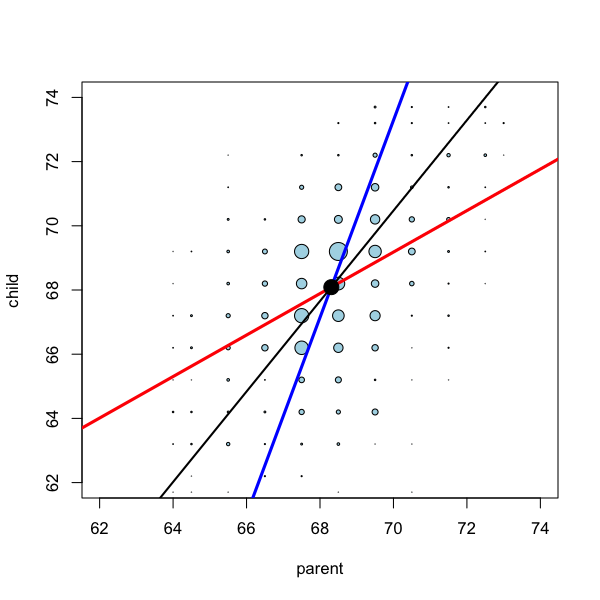